# ML for Public Health hw3

Grace Bai

2022-04-25

```r
library(readr)
library(tidyverse)
library(ranger)
library(randomForest)
library(caret)
# install.packages("doParallel")
library(doParallel)
```

```r
library(ggplot2)
```

## 1. Using the same dataset from the last homework, `HW2_dataset.csv`, estimate a new predictor using the random forests algorithm.

### a. How does the mean squared error estimate for your random forests predictor compare with the regularized regression estimates from HW2?

```r
## deal with data first
## Tree-based algorithms make splits in the data where appropriate/useful. There is no need to rescale data.
data <- read_csv("HW2_dataset.csv")
data <- data %>% mutate_if(is.character, as.factor)
head(data)
```

```
## # A tibble: 6 x 126
##        Y    X1     X2     X3    X4    X5     X6     X7     X8     X9    X10
##    <dbl> <dbl>  <dbl>  <dbl> <dbl> <dbl>  <dbl>  <dbl>  <dbl>  <dbl>  <dbl>
## 1  3.50   -0.5  0.194 -3.00   -2.5 0.478 -0.936  1.08  -2.03   0.743 -0.978
## 2 33.1    -0.3 -2.64  -0.779   1.3 0.42   1.81   2.39   0.14  -1.42  -4.82
## 3 -0.949  -0.6  2.47   1.36    0.8 0.561 -2.61  -0.145  3.48  -1.20   0.861
## 4 -6.43   -3.3  0.229 -3.60    5.2 0.424 -0.98   1.67  -1.08   0.392 -1.58
## 5 31.9    -1.5  1.12   2.47    2.2 0.553  0.81   1.17  -0.971  0.2    0.482
## 6 21.2    -3.2  2.26   0.368  -0.7 0.425  0.347 -0.601 -0.806 -0.41  -2.82
## # ... with 115 more variables: X11 <dbl>, X12 <dbl>, X13 <dbl>, X14 <dbl>,
## #   X15 <dbl>, X16 <dbl>, X17 <dbl>, X18 <dbl>, X19 <dbl>, X20 <dbl>,
## #   X21 <dbl>, X22 <dbl>, X23 <dbl>, X24 <dbl>, X25 <dbl>, X26 <dbl>,
## #   X27 <dbl>, X28 <dbl>, X29 <dbl>, X30 <dbl>, X31 <dbl>, X32 <dbl>,
## #   X33 <dbl>, X34 <dbl>, X35 <dbl>, X36 <dbl>, X37 <dbl>, X38 <dbl>,
## #   X39 <dbl>, X40 <dbl>, X41 <dbl>, X42 <dbl>, X43 <dbl>, X44 <dbl>,
## #   X45 <dbl>, X46 <dbl>, X47 <dbl>, X48 <dbl>, X49 <dbl>, X50 <dbl>, ...
```

#### Train-test splpit

```r
#train test split
set.seed(424)
in.train <- createDataPartition(data$Y, p = 0.80, list = F)
train <- data[in.train,]
test <- data[-in.train,]
```

#### Random forest

```r
## baseline; try out model first
set.seed(1)
rf <- ranger(formula = Y ~ .,
             data = train,
             num.trees = 500,
             mtry = 11,
             min.node.size = 1,
             # num.threads = 4
             )

predictions <- predict(rf, data = test)
mean((predictions$predictions - test$Y)^2)
```

```
## [1] 155.1602
```

#### Tuning mtry and min.node.size (tree depth) using ranger and caret

```r
#parallel processing
cl <- makePSOCKcluster(6)
registerDoParallel(cl)

#create tune grid and search through a wide variety of parameters
tuneGrid <- data.frame(
  .mtry = c(11:60),
  .splitrule = "variance",
  .min.node.size = c(1:50)
)

#random forest with caret and ranger
set.seed(1)
rf <- train(
  Y ~ .,
  tuneGrid = tuneGrid,
  data = train,
  method = "ranger",
  metric = "RMSE",
  trControl = trainControl(method = "cv",
                           number = 10,
                           verboseIter = T)
)
```

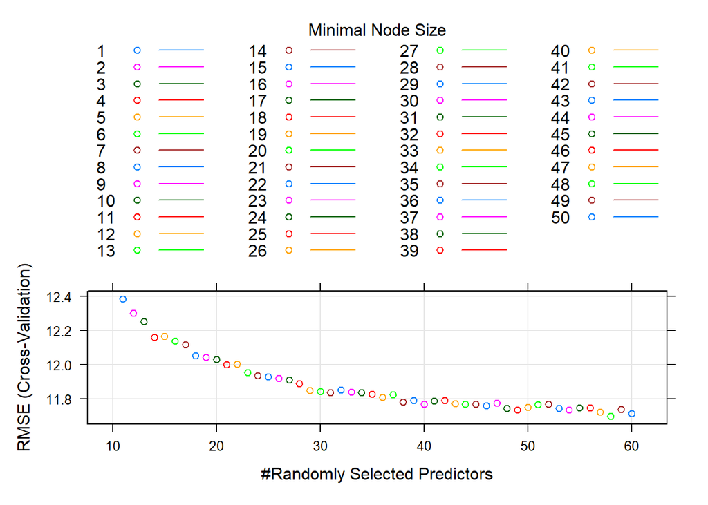

```r
plot(rf)
```

```r
rf.predictions <- predict(rf, newdata = test)
mean((rf.predictions - test$Y)^2)
```

```
## [1] 128.4652
```

#### Tuning ntrees

Since we know that larger mtry values generate lower RMSE, for tuning the number of trees, we can start from a larger mtry value, even though the number of trees might interact with mtry.

```r
# #optimal tree number
# tunegrid <- expand.grid(.mtry = 54
#                         # .splitrule = "variance",
#                         # .min.node.size = 44
#                         )
# models <- list()
# control <- trainControl(method = "cv",
#                         number = 10,
#                         # repeats = 1,
#                         search = "grid")
#
# for (ntree in c(500, 1500, 2500)) {
#   set.seed(142)
#   fit <- train(Y~.,
#                data=train,
#                method="rf",
#                metric="RMSE",
#                tuneGrid=tunegrid,
#                trControl=control,
#                ntree=ntree)
#   tree <- toString(ntree)
#   models[[tree]] <- fit
# }
#
# results <- resamples(models)
# summary(results)
# dotplot(results)
```

Although tuning ntrees and mtry & min.node.size (tree depth) is not the best way to tune parameters and tuning parameters do interact with each other, tuning the number of trees separately nevertheless saved time on the tuning process as a whole (as the length of trees needed to match the length of mtry and min.node.size within the tuning data frame). Moreover, mtry and tree depth are more important parameters than ntree when it comes to tuning random forest models.

#### Final model

Let’s use a combination of the best parameters from each tuning step above to produce our final model.

```r
final.rf <- ranger(formula = Y ~ .,
             data = train,
             num.trees = 500,
             mtry = rf$bestTune[,1],
             min.node.size = rf$bestTune[,3],
             num.threads = 6
             )
rf.predictions <- predict(rf, newdata = test)
mean((rf.predictions - test$Y)^2)
```

```
## [1] 128.4652
```

```r
stopCluster(cl)
```

### b. Create a scatterplot comparing the predicted values from your random forests to your predictions from the lasso regression and describe how they are similar or different.

```r
#code from last time
#train-test split for regularization methods
library(glmnet)
hw2 <- read_csv("HW2_dataset.csv")
set.seed(1)
in.train <- createDataPartition(hw2$Y, p = .80, list = F)

train.reg <- hw2[in.train,]
y.train <- as.numeric(train$Y)
train.reg <- model.matrix(Y ~ ., data = train)[,-1]
test.reg <- hw2[-in.train,]
y.test <- as.numeric(test$Y)
test.reg <- model.matrix(Y ~ ., data = test)[,-1]

#lasso predictions
lasso <- cv.glmnet(train.reg,
                   y.train,
                   alpha = 1,
                   standardize = T,
                   type.measure = "mse",
                   nfolds = 5)

lasso.pred <- predict(lasso,
                      s = lasso$lambda.1se,
                      newx = test.reg)


#random forest predictions
rf.predictions <- data.frame(rf.predictions)

#all predictions
all.pred <- data.frame(rf.pred = rf.predictions,
           lasso.pred = lasso.pred,
           Y = test$Y)
colnames(all.pred) <- c("random_forest","lasso","Y")
summary(all.pred)
```

```
##  random_forest        lasso              Y
##  Min.   :-1.547   Min.   :-6.607   Min.   :-25.064
##  1st Qu.: 7.058   1st Qu.: 7.971   1st Qu.:  3.945
##  Median :13.306   Median :12.842   Median : 13.591
##  Mean   :12.790   Mean   :13.404   Mean   : 13.454
##  3rd Qu.:18.564   3rd Qu.:18.825   3rd Qu.: 22.897
##  Max.   :28.755   Max.   :31.612   Max.   : 55.564
```

#### Scatterplot

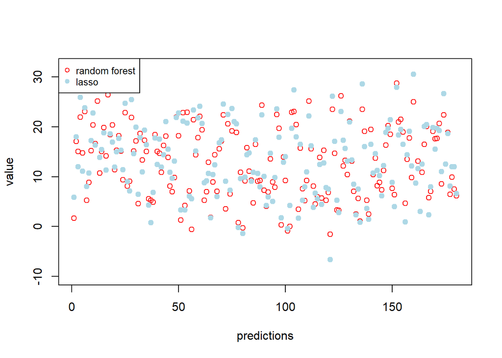

```r
#create scatterplot
plot(all.pred$random_forest, col = "red", pch = 1,
     xlab = "predictions", ylab = "value",
     ylim = c(-10,32)
     )
points(all.pred$lasso, col = "light blue", pch = 19)
legend("topleft", legend=c("random forest", "lasso"),
       col=c("red", "light blue"), pch=c(1,19), cex=0.8)
lines(mean(all.pred$Y), mean(all.pred$Y), lwd = 3, col = "red")
```

Discussion: Both lasso and random forest predictions seem to have similar mean values, with lasso producing more “extreme” minimum and maximum estimates (smaller low values and larger high values) than random forest.

## 3. Finally, for this same dataset, estimate a super learner ensemble with at least 10 different candidate learners in the library, these can be a mixture of different algorithms and different values of tuning parameters to create the 10 different candidates.

### Using a nested cross-validation approach (like the CV.SuperLearner function), how does the 10-fold cross-validated estimate of the mean squared error compare between the final ensemble and the individual candidate algorithms?